# Bandwidth Selection

```r
getwd()
```

```
## [1] "/Users/emmalandry/Documents/Imperial/UROP/crim/BandwidthSelection"
```

```r
library(here)
```

Load the oackages used for bandwidth selection

```r
library(spatstat)
library(spatstat.data)
library(nlme)
library(rpart)
library (sp)
```

In the whole document, we use the data with holidays as it has been noticed that the surges in holidays mostly occured in AGLS data (fireworks, celebratory gunshots) rather than corresponding to an actual higher number of assaults.

**Washington DC: incidents Data 2016 -2018** First loading the data

```r
data_WDC <- readRDS(here("gun_shootings_multicity/data/ready_for_modeling/washington_incidents_2016-2018_with_holidays.rds"))
```

We start with looking at different methods that estimate the bandwidth for timess. We use the default Gaussian Kernel, estimate the density at 1024 points.

```r
times_WDC <- data.matrix(data_WDC$Time)

#NRD0
WDC_time_est1 <- density (times_WDC, n =1024)
WDC_time_est1$bw
```

```
## [1] 1452.144
```

```r
plot(WDC_time_est1, col = "slateblue1", lwd = 1.5, ylim = c(0, 6*10^(-5)), main = "Kernel Density Estimation- Washington DC", xlab = "Observation" )

#NRD
WDC_time_est2 <- density (times_WDC, bw = "nrd",n =1024)
WDC_time_est2$bw
```

```
## [1] 1710.303
```

```r
lines(WDC_time_est2, col = "violet", lwd = 1.5 )

#UCV
WDC_time_est3 <- density (times_WDC, bw = "ucv",n =1024)
WDC_time_est3$bw
```

```
## [1] 347.6725
```

```r
lines(WDC_time_est3, col = "steelblue1", lwd = 1.5 )

#BCV
WDC_time_est4 <- density (times_WDC, bw = "bcv",n =1024)
WDC_time_est4$bw
```

```
## [1] 994.1864
```

```r
lines(WDC_time_est4, col ="royalblue3", lwd = 1.5 )

#SJ
WDC_time_est5 <- density (times_WDC, bw = "SJ",n =1024)
WDC_time_est5$bw
```

```
## [1] 868.8389
```

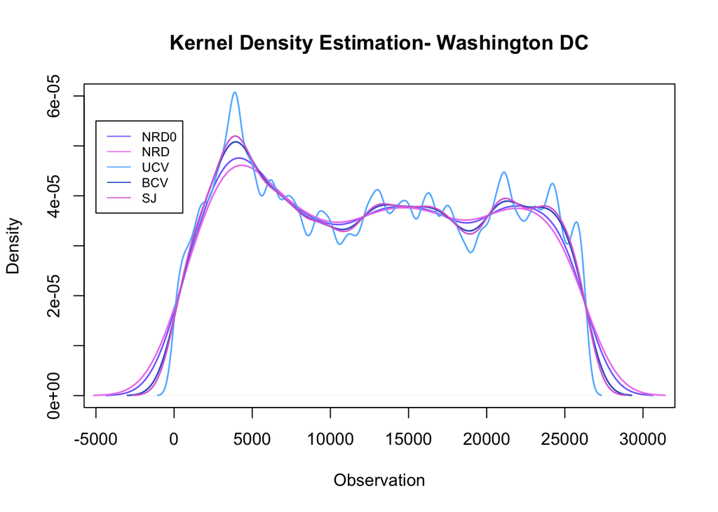

```r
lines(WDC_time_est5, col = "orchid", lwd = 1.5 )

legend(-5000, 5.5*10^(-5), legend = c("NRD0", "NRD", "UCV", "BCV", "SJ"), col = c("slateblue1", "violet", "steelblue1", "royalblue3","orchid"), lty = 1, cex = 0.75)
```

We now continue by looking at different methods that estimate the bandwidth for the spatial locations.

```r
X_min_WDC <- min(data_WDC$X)
X_max_WDC <- max(data_WDC$X)
Y_min_WDC <- min(data_WDC$Y)
Y_max_WDC <- max(data_WDC$Y)

loc_WDC <- SpatialPoints(cbind(data_WDC$X, data_WDC$Y))
loc_WDC_ppp <- as.ppp(as.data.frame(loc_WDC), c(X_min_WDC, X_max_WDC, Y_min_WDC, Y_max_WDC))
#Diggle
WDC_loc_est1 <- bw.diggle(loc_WDC_ppp)
WDC_loc_est1
```

```
##       sigma
## 0.004069716
```

```r
#ppl
WDC_loc_est2 <- bw.ppl(loc_WDC_ppp)
WDC_loc_est2
```

```
##     sigma
## 0.2098579
```

```r
#scott
WDC_loc_est3 <- bw.scott(loc_WDC_ppp)
WDC_loc_est3
```

```
##   sigma.x   sigma.y
## 0.7742812 1.1042186
```

```r
#CvL
WDC_loc_est4 <- bw.CvL(loc_WDC_ppp)
WDC_loc_est4
```

```
##   sigma
## 3.18258
```

**Chicago: incidents data 2016-2018**

```r
data_CHI <- readRDS(here("gun_shootings_multicity/data/ready_for_modeling/chicago_incidents_2016-2018_with_holidays.rds"))
```

We now look at the estimates for time:

```r
times_CHI <- data.matrix(data_CHI$Time)

#NRD0
CHI_time_est1 <- density (times_CHI, n =1024)
CHI_time_est1$bw
```

```
## [1] 1104.298
```

```r
plot(CHI_time_est1, col = "slateblue1", lwd = 1.5, ylim = c(0, 6*10^(-5)), main = "Kernel Density Estimation- Chicago", xlab = "Observation" )

#NRD
CHI_time_est2 <- density (times_CHI, bw = "nrd",n =1024)
CHI_time_est2$bw
```

```
## [1] 1300.618
```

```r
lines(CHI_time_est2, col = "violet", lwd = 1.5 )

#UCV
CHI_time_est3 <- density (times_CHI, bw = "ucv",n =1024)
CHI_time_est3$bw
```

```
## [1] 145.9612
```

```r
lines(CHI_time_est3, col = "steelblue1", lwd = 1.5 )

#BCV
CHI_time_est4 <- density (times_CHI, bw = "bcv",n =1024)
CHI_time_est4$bw
```

```
## [1] 685.4067
```

```r
lines(CHI_time_est4, col ="royalblue3", lwd = 1.5 )

#SJ
CHI_time_est5 <- density (times_CHI, bw = "SJ",n =1024)
CHI_time_est5$bw
```

```
## [1] 534.2438
```

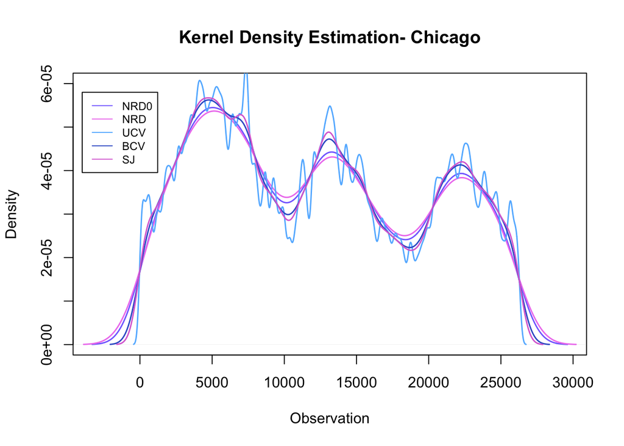

```r
lines(CHI_time_est5, col = "orchid", lwd = 1.5 )

legend(-4000, 5.8*10^(-5), legend = c("NRD0", "NRD", "UCV", "BCV", "SJ"), col = c("slateblue1", "violet", "steelblue1", "royalblue3","orchid"), lty = 1, cex = 0.75)
```

We now continue by looking at different methods that estimate the bandwidth for the spatial locations.

```r
X_min_CHI <- min(data_CHI$X)
X_max_CHI <- max(data_CHI$X)
Y_min_CHI <- min(data_CHI$Y)
Y_max_CHI <- max(data_CHI$Y)

loc_CHI <- SpatialPoints(cbind(data_CHI$X, data_CHI$Y))
loc_CHI_ppp <- as.ppp(as.data.frame(loc_CHI), c(X_min_CHI, X_max_CHI, Y_min_CHI, Y_max_CHI))
#Diggle
CHI_loc_est1 <- bw.diggle(loc_CHI_ppp)
CHI_loc_est1
```

```
##      sigma
## 0.01868343
```

```r
#ppl
CHI_loc_est2 <- bw.ppl(loc_CHI_ppp)
CHI_loc_est2
```

```
##     sigma
## 0.2685644
```

```r
#scott
CHI_loc_est3 <- bw.scott(loc_CHI_ppp)
CHI_loc_est3
```

```
##  sigma.x  sigma.y
## 1.043754 1.873928
```

```r
#CvL
CHI_loc_est4 <- bw.CvL(loc_CHI_ppp)
CHI_loc_est4
```

```
##    sigma
## 11.61958
```

**Los Angeles: incidents date 2016- 2018**

```r
data_LA <- readRDS(here("gun_shootings_multicity/data/ready_for_modeling/losangeles_incidents_2016-2018_with_holidays.rds"))
```

We compute the bandwidth estimates for time :

```r
times_LA <- data.matrix(data_LA$Time)

#NRD0
LA_time_est1 <- density (times_LA, n =1024)
LA_time_est1$bw
```

```
## [1] 1197.853
```

```r
plot(LA_time_est1, col = "slateblue1", lwd = 1.5, ylim = c(0, 6*10^(-5)), main = "Kernel Density Estimation- Los Angeles", xlab = "Observation" )

#NRD
LA_time_est2 <- density (times_LA, bw = "nrd",n =1024)
LA_time_est2$bw
```

```
## [1] 1410.805
```

```r
lines(LA_time_est2, col = "violet", lwd = 1.5 )

#UCV
LA_time_est3 <- density (times_LA, bw = "ucv",n =1024)
LA_time_est3$bw
```

```
## [1] 165.2128
```

```r
lines(LA_time_est3, col = "steelblue1", lwd = 1.5 )

#BCV
LA_time_est4 <- density (times_LA, bw = "bcv",n =1024)
LA_time_est4$bw
```

```
## [1] 590.361
```

```r
lines(LA_time_est4, col ="royalblue3", lwd = 1.5 )

#SJ
LA_time_est5 <- density (times_LA, bw = "SJ",n =1024)
LA_time_est5$bw
```

```
## [1] 547.2805
```

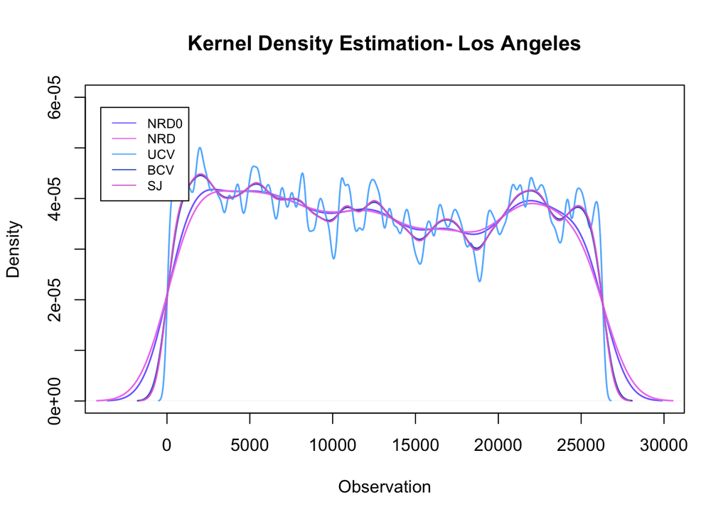

```r
lines(LA_time_est5, col = "orchid", lwd = 1.5 )

legend(-4000, 5.8*10^(-5), legend = c("NRD0", "NRD", "UCV", "BCV", "SJ"), col = c("slateblue1", "violet", "steelblue1", "royalblue3","orchid"), lty = 1, cex = 0.75)
```

And now the bandwidth estimations for the locations:

```r
X_min_LA <- min(data_LA$X)
X_max_LA <- max(data_LA$X)
Y_min_LA <- min(data_LA$Y)
Y_max_LA <- max(data_LA$Y)

loc_LA <- SpatialPoints(cbind(data_LA$X, data_LA$Y))
loc_LA_ppp <- as.ppp(as.data.frame(loc_LA), c(X_min_LA, X_max_LA, Y_min_LA, Y_max_LA))
#Diggle
LA_loc_est1 <- bw.diggle(loc_LA_ppp)
LA_loc_est1
```

```
##      sigma
## 0.01110606
```

```r
#ppl
LA_loc_est2 <- bw.ppl(loc_LA_ppp)
LA_loc_est2
```

```
##    sigma
## 0.465998
```

```r
#scott
LA_loc_est3 <- bw.scott(loc_LA_ppp)
LA_loc_est3
```

```
##  sigma.x  sigma.y
## 1.831233 2.954612
```

```r
#CvL
LA_loc_est4 <- bw.CvL(loc_LA_ppp)
LA_loc_est4
```

```
##    sigma
## 13.45259
```

**New York City : incidents data 2016- 2018**

```r
data_NYC <- readRDS(here("gun_shootings_multicity/data/ready_for_modeling/nyc_incidents_2016-2018_with_holidays.rds"))
```

Bandwidth estimates for times :

```r
times_NYC <- data.matrix(data_NYC$Time)

#NRD0
NYC_time_est1 <- density (times_NYC, n =1024)
NYC_time_est1$bw
```

```
## [1] 1424.287
```

```r
plot(NYC_time_est1, col = "slateblue1", lwd = 1.5, ylim = c(0, 6*10^(-5)), main = "Kernel Density Estimation- New York City", xlab = "Observation" )

#NRD
NYC_time_est2 <- density (times_NYC, bw = "nrd",n =1024)
NYC_time_est2$bw
```

```
## [1] 1677.494
```

```r
lines(NYC_time_est2, col = "violet", lwd = 1.5 )

#UCV
NYC_time_est3 <- density (times_NYC, bw = "ucv",n =1024)
NYC_time_est3$bw
```

```
## [1] 385.9115
```

```r
lines(NYC_time_est3, col = "steelblue1", lwd = 1.5 )

#BCV
NYC_time_est4 <- density (times_NYC, bw = "bcv",n =1024)
NYC_time_est4$bw
```

```
## [1] 803.4122
```

```r
lines(NYC_time_est4, col ="royalblue3", lwd = 1.5 )

#SJ
NYC_time_est5 <- density (times_NYC, bw = "SJ",n =1024)
NYC_time_est5$bw
```

```
## [1] 742.3247
```

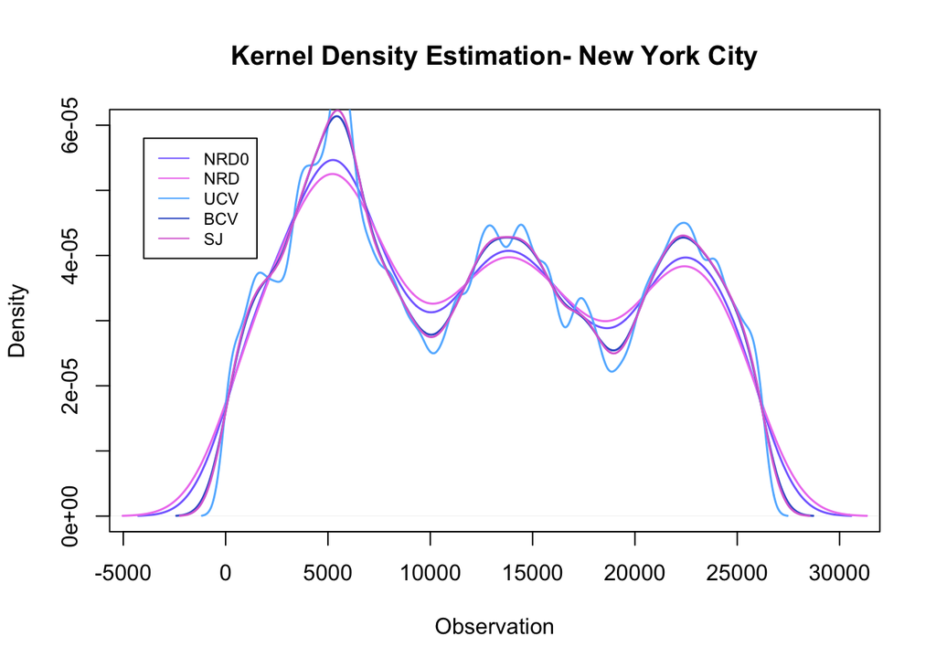

```r
lines(NYC_time_est5, col = "orchid", lwd = 1.5 )

legend(-4000, 5.8*10^(-5), legend = c("NRD0", "NRD", "UCV", "BCV", "SJ"), col = c("slateblue1", "violet", "steelblue1", "royalblue3","orchid"), lty = 1, cex = 0.75)
```

The bandwidth for locations:

```r
X_min_NYC <- min(data_NYC$X)
X_max_NYC <- max(data_NYC$X)
Y_min_NYC <- min(data_NYC$Y)
Y_max_NYC <- max(data_NYC$Y)

loc_NYC <- SpatialPoints(cbind(data_NYC$X, data_NYC$Y))
loc_NYC_ppp <- as.ppp(as.data.frame(loc_NYC), c(X_min_NYC, X_max_NYC, Y_min_NYC, Y_max_NYC))
#Diggle
NYC_loc_est1 <- bw.diggle(loc_NYC_ppp)
NYC_loc_est1
```

```
##     sigma
## 0.1328938
```

```r
#ppl
NYC_loc_est2 <- bw.ppl(loc_NYC_ppp)
NYC_loc_est2
```

```
##     sigma
## 0.5918007
```

```r
#scott
NYC_loc_est3 <- bw.scott(loc_NYC_ppp)
NYC_loc_est3
```

```
##  sigma.x  sigma.y
## 1.585860 2.601194
```

```r
#CvL
NYC_loc_est4 <- bw.CvL(loc_NYC_ppp)
NYC_loc_est4
```

```
##    sigma
## 4.223469
```

**Philadelphia: incidents data 2016- 2018**

```r
data_PHILLY <- readRDS(here("gun_shootings_multicity/data/ready_for_modeling/philadelphia_incidents_2016-2018_with_holidays.rds"))
```

Bandwidth estimates for times:

```r
times_PHILLY <- data.matrix(data_PHILLY$Time)

#NRD0
PHILLY_time_est1 <- density (times_PHILLY, n =1024)
PHILLY_time_est1$bw
```

```
## [1] 1149.593
```

```r
plot(PHILLY_time_est1, col = "slateblue1", lwd = 1.5, ylim = c(0, 6*10^(-5)), main = "Kernel Density Estimation- Philadelphia", xlab = "Observation" )

#NRD
PHILLY_time_est2 <- density (times_PHILLY, bw = "nrd",n =1024)
PHILLY_time_est2$bw
```

```
## [1] 1353.965
```

```r
lines(PHILLY_time_est2, col = "violet", lwd = 1.5 )

#UCV
PHILLY_time_est3 <- density (times_PHILLY, bw = "ucv",n =1024)
PHILLY_time_est3$bw
```

```
## [1] 151.948
```

```r
lines(PHILLY_time_est3, col = "steelblue1", lwd = 1.5 )

#BCV
PHILLY_time_est4 <- density (times_PHILLY, bw = "bcv",n =1024)
PHILLY_time_est4$bw
```

```
## [1] 757.9391
```

```r
lines(PHILLY_time_est4, col ="royalblue3", lwd = 1.5 )

#SJ
PHILLY_time_est5 <- density (times_PHILLY, bw = "SJ",n =1024)
PHILLY_time_est5$bw
```

```
## [1] 598.358
```

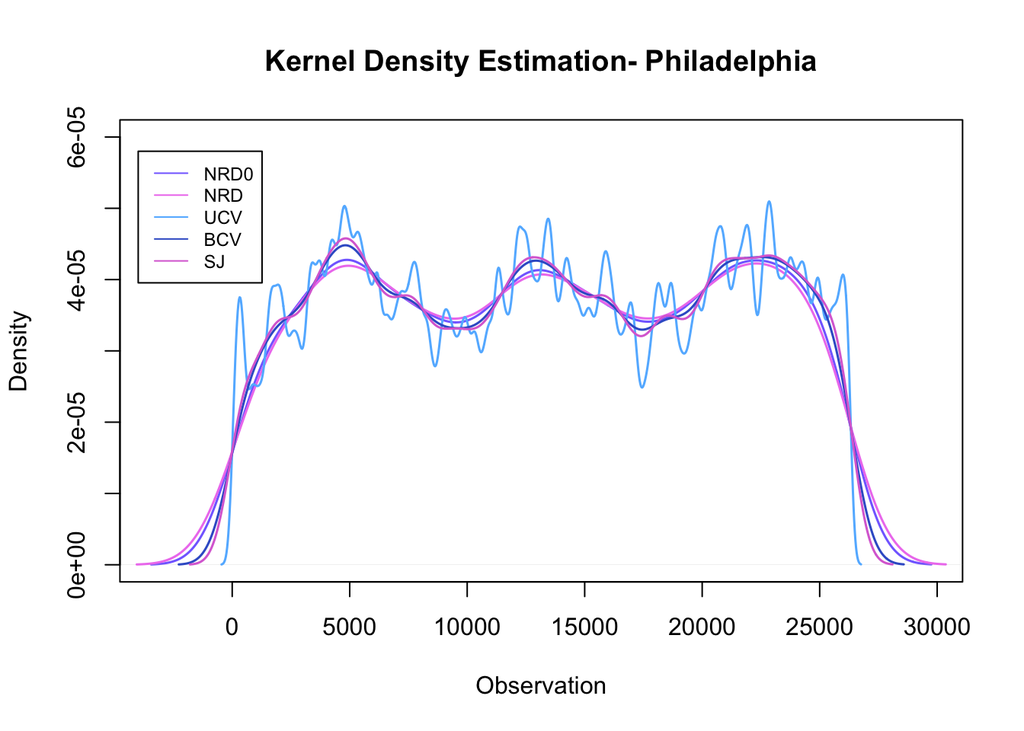

```r
lines(PHILLY_time_est5, col = "orchid", lwd = 1.5 )

legend(-4000, 5.8*10^(-5), legend = c("NRD0", "NRD", "UCV", "BCV", "SJ"), col = c("slateblue1", "violet", "steelblue1", "royalblue3","orchid"), lty = 1, cex = 0.75)
```

Location bandwidth estimates:

```r
X_min_PHILLY <- min(data_PHILLY$X)
X_max_PHILLY <- max(data_PHILLY$X)
Y_min_PHILLY <- min(data_PHILLY$Y)
Y_max_PHILLY <- max(data_PHILLY$Y)

loc_PHILLY <- SpatialPoints(cbind(data_PHILLY$X, data_PHILLY$Y))
loc_PHILLY_ppp <- as.ppp(as.data.frame(loc_PHILLY), c(X_min_PHILLY, X_max_PHILLY, Y_min_PHILLY, Y_max_PHILLY))
#Diggle
PHILLY_loc_est1 <- bw.diggle(loc_PHILLY_ppp)
PHILLY_loc_est1
```

```
##      sigma
## 0.03276858
```

```r
#ppl
PHILLY_loc_est2 <- bw.ppl(loc_PHILLY_ppp)
PHILLY_loc_est2
```

```
##     sigma
## 0.1903838
```

```r
#scott
PHILLY_loc_est3 <- bw.scott(loc_PHILLY_ppp)
PHILLY_loc_est3
```

```
##   sigma.x   sigma.y
## 1.0176236 0.9991372
```

```r
#CvL
PHILLY_loc_est4 <- bw.CvL(loc_PHILLY_ppp)
PHILLY_loc_est4
```

```
##    sigma
## 8.842905
```

```r
data_DEN <- readRDS(here("gun_shootings_multicity/data/ready_for_modeling/denver_incidents_2016-2018_no_dups_with_holidays.rds"))
```

We notice it is much smaller than the previous data sets.

Bandwidth estimations for times:

```r
times_DEN <- data.matrix(data_DEN$Time)

#NRD0
DEN_time_est1 <- density (times_DEN, n =1024)
DEN_time_est1$bw
```

```
## [1] 2003.053
```

```r
plot(DEN_time_est1, col = "slateblue1", lwd = 1.5, ylim = c(0, 6*10^(-5)), main = "Kernel Density Estimation- Denver", xlab = "Observation" )

#NRD
DEN_time_est2 <- density (times_DEN, bw = "nrd",n =1024)
DEN_time_est2$bw
```

```
## [1] 2359.152
```

```r
lines(DEN_time_est2, col = "violet", lwd = 1.5 )

#UCV
DEN_time_est3 <- density (times_DEN, bw = "ucv",n =1024)
DEN_time_est3$bw
```

```
## [1] 1378.859
```

```r
lines(DEN_time_est3, col = "steelblue1", lwd = 1.5 )

#BCV
DEN_time_est4 <- density (times_DEN, bw = "bcv",n =1024)
DEN_time_est4$bw
```

```
## [1] 1917.33
```

```r
lines(DEN_time_est4, col ="royalblue3", lwd = 1.5 )

#SJ
DEN_time_est5 <- density (times_DEN, bw = "SJ",n =1024)
DEN_time_est5$bw
```

```
## [1] 1467.437
```

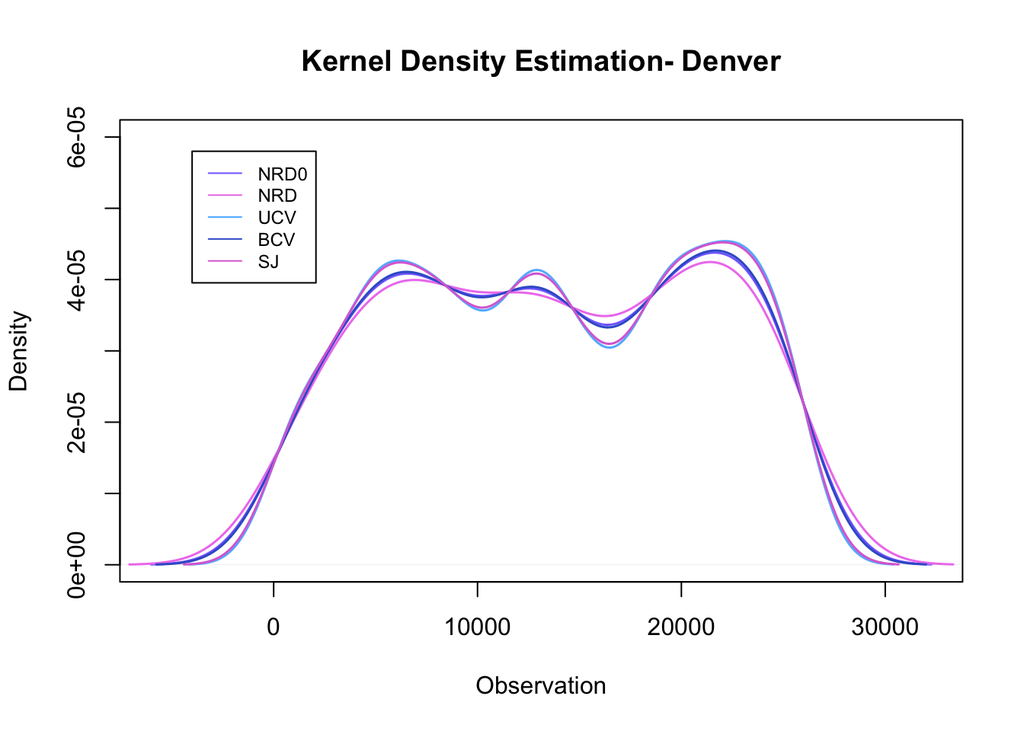

```r
lines(DEN_time_est5, col = "orchid", lwd = 1.5 )

legend(-4000, 5.8*10^(-5), legend = c("NRD0", "NRD", "UCV", "BCV", "SJ"), col = c("slateblue1", "violet", "steelblue1", "royalblue3","orchid"), lty = 1, cex = 0.75)
```

Bandwidth estimation for locations:

```r
X_min_DEN <- min(data_DEN$X)
X_max_DEN <- max(data_DEN$X)
Y_min_DEN <- min(data_DEN$Y)
Y_max_DEN <- max(data_DEN$Y)

loc_DEN <- SpatialPoints(cbind(data_DEN$X, data_DEN$Y))
loc_DEN_ppp <- as.ppp(as.data.frame(loc_DEN), c(X_min_DEN, X_max_DEN, Y_min_DEN, Y_max_DEN))
#Diggle
DEN_loc_est1 <- bw.diggle(loc_DEN_ppp)
DEN_loc_est1
```

```
##     sigma
## 0.1594485
```

```r
#ppl
DEN_loc_est2 <- bw.ppl(loc_DEN_ppp)
DEN_loc_est2
```

```
##    sigma
## 0.458915
```

```r
#scott
DEN_loc_est3 <- bw.scott(loc_DEN_ppp)
DEN_loc_est3
```

```
##  sigma.x  sigma.y
## 2.312231 1.566554
```

```r
#CvL
DEN_loc_est4 <- bw.CvL(loc_DEN_ppp)
DEN_loc_est4
```

```
##    sigma
## 4.141542
```

We now want to visualize the bandwidths for each city, with different methods. We can generate some plots using ggplot2.

```r
library(ggplot2)
library(dplyr)
library (tidyr)
library(RColorBrewer)
```

Create data frames with the bandwidth data.

```r
times_df <- data.frame("City"= c("Washington DC", "Chicago", "Los Angeles","New York City", "Philadelphia", "Denver"), "NRD0" = c(WDC_time_est1$bw, CHI_time_est1$bw, LA_time_est1$bw, NYC_time_est1$bw,PHILLY_time_est1$bw, DEN_time_est1$bw), "NRD"= c(WDC_time_est2$bw, CHI_time_est2$bw, LA_time_est2$bw, NYC_time_est2$bw,PHILLY_time_est2$bw, DEN_time_est2$bw), "UCV"= c(WDC_time_est3$bw, CHI_time_est3$bw, LA_time_est3$bw, NYC_time_est3$bw,PHILLY_time_est3$bw, DEN_time_est3$bw), "BCV"= c(WDC_time_est4$bw, CHI_time_est4$bw, LA_time_est4$bw, NYC_time_est4$bw,PHILLY_time_est4$bw, DEN_time_est4$bw), "SJ"= c(WDC_time_est5$bw, CHI_time_est5$bw, LA_time_est5$bw, NYC_time_est5$bw,PHILLY_time_est5$bw, DEN_time_est5$bw))

loc_df <- data.frame("City"= c("Washington DC", "Chicago", "Los Angeles","New York City", "Philadelphia", "Denver"), "Diggle" = c(WDC_loc_est1, CHI_loc_est1, LA_loc_est1, NYC_loc_est1,PHILLY_loc_est1, DEN_loc_est1), "PPL"= c(WDC_loc_est2, CHI_loc_est2, LA_loc_est2, NYC_loc_est2,PHILLY_loc_est2, DEN_loc_est2), "CvL"= c(WDC_loc_est4, CHI_loc_est4, LA_loc_est4, NYC_loc_est4,PHILLY_loc_est4, DEN_loc_est4), "Scott X"= c(WDC_loc_est3[1:1], CHI_loc_est3[1:1], LA_loc_est3[1:1], NYC_loc_est3[1:1],PHILLY_loc_est3[1:1], DEN_loc_est3[1:1]),"Scott Y"= c(WDC_loc_est3[2:2], CHI_loc_est3[2:2], LA_loc_est3[2:2], NYC_loc_est3[2:2],PHILLY_loc_est3[2:2], DEN_loc_est3[2:2]) )
```

We now proceed to generating some barplots. We start with the time bandwidth.

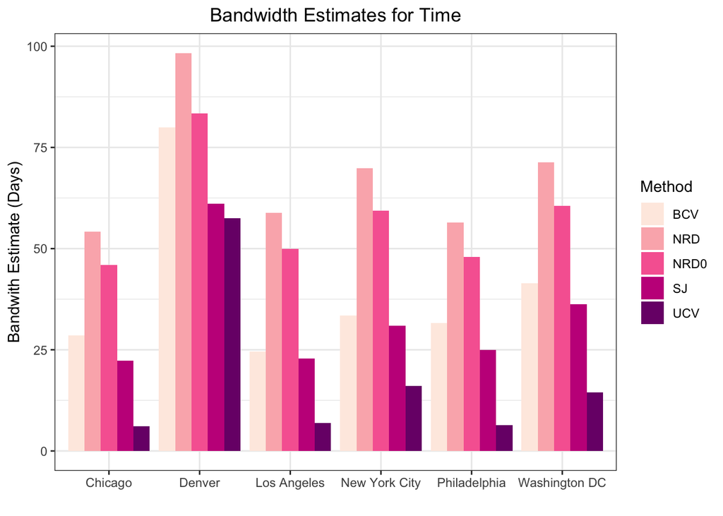

```r
times_df %>%
  gather("Type", "Value",-City) %>%
  mutate("Days" = Value /24) %>%
  ggplot(aes(City, Days, fill = Type)) +
  geom_bar(position = "dodge", stat = "identity") +
  theme_bw() +
  scale_fill_brewer(palette = "RdPu") +
  labs(title = "Bandwidth Estimates for Time", x= "", y= "Bandwith Estimate (Days)", fill = "Method") +
  theme(plot.title = element_text(hjust = 0.5))
```

We continue with plotting the location bandwidth. We note that the Scott Estimate is divided into 2 bars corresponding to the X estimate and the Y estimate. Since CvL gives much larger values, we do not add it to the plot, and plot it in a separate histogram.

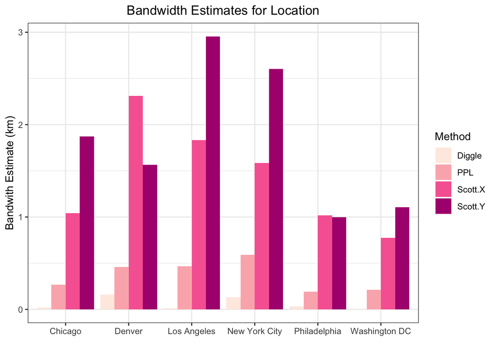

```r
loc_df_noCvL <- subset(loc_df, select = -CvL)
loc_df_noCvL %>%
  gather("Type", "Value",-City) %>%
  ggplot(aes(City, Value, fill = Type)) +
  geom_bar(position = "dodge", stat = "identity") +
  theme_bw() +
  scale_fill_brewer(palette = "RdPu") +
  labs(title = "Bandwidth Estimates for Location", x= "", y= "Bandwith Estimate (km)", fill = "Method") +
  theme(plot.title = element_text(hjust = 0.5))
```

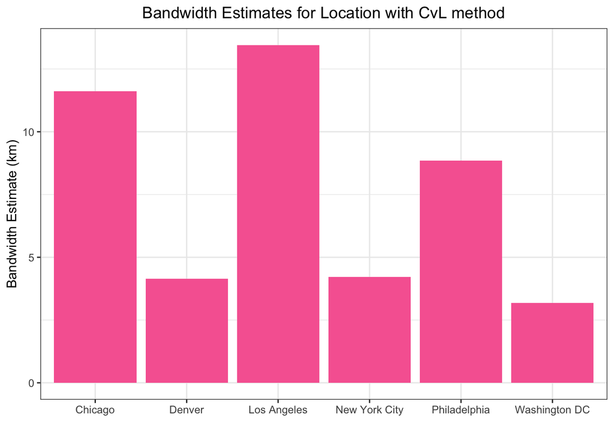

```r
data.frame("City" = loc_df$City, "CvL"= loc_df$CvL)  %>%
  ggplot (aes(x= City, y = CvL)) +
  geom_bar(position = "dodge", stat = "identity", fill = brewer.pal(n = 4, name= "RdPu")[3]) +
  theme_bw()+
  labs(title ="Bandwidth Estimates for Location with CvL method", x = "", y = "Bandwidth Estimate (km)")+
  theme(plot.title = element_text(hjust = 0.5))
```